# R for Data Science (Hadley Wickham) - Chapter 7 Exercises

```r
library(tidyverse)
library(nycflights13)
```

## 7.3.4 Exercises

##### Explore the distribution of each of the x, y, and z variables in diamonds. What do you learn? Think about a diamond and how you might decide which dimension is the length, width, and depth.

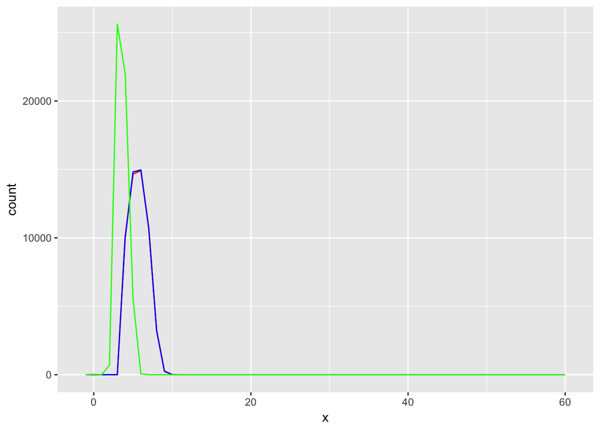

```r
ggplot(diamonds) +
  geom_freqpoly(aes(x=x), color = "red", binwidth = 1) +
  geom_freqpoly(aes(x=y), color = "blue", binwidth = 1) +
  geom_freqpoly(aes(x=z), color = "green", binwidth = 1)
```

##### Explore the distribution of price. Do you discover anything unusual or surprising? (Hint: Carefully think about the binwidth and make sure you try a wide range of values.)

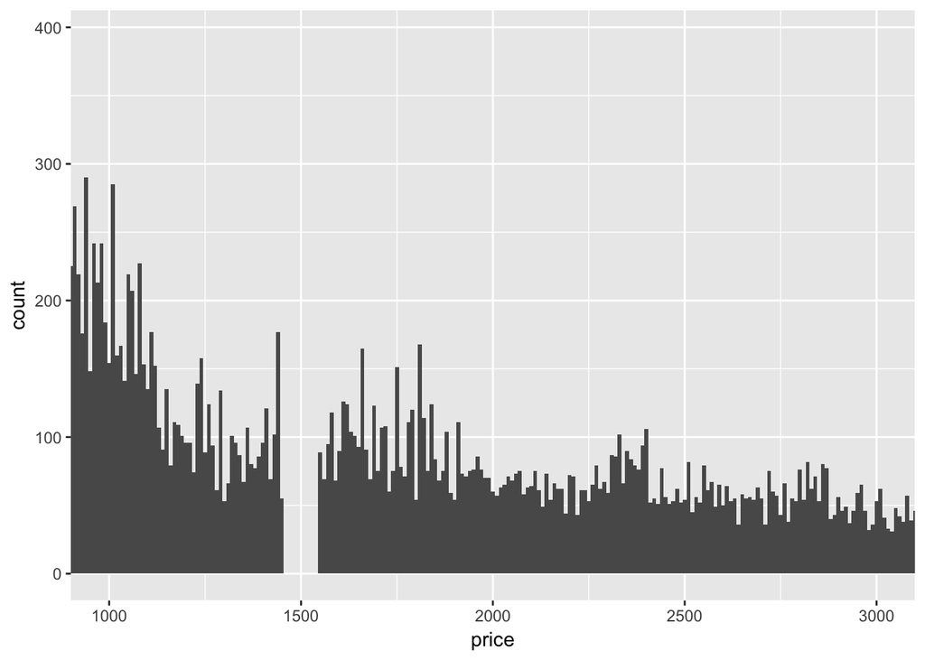

```r
ggplot(diamonds) +
  geom_histogram(aes(x=price), binwidth = 10) +
  coord_cartesian(xlim=c(1000,3000))
```

- There’s a gap near $1500, no idea why

##### How many diamonds are 0.99 carat? How many are 1 carat? What do you think is the cause of the difference?

```r
diamonds %>%
  filter(between(carat,0.98,1.01)) %>%
  count(carat)
```

```
## # A tibble: 4 x 2
##   carat     n
##   <dbl> <int>
## 1 0.980    31
## 2 0.990    23
## 3 1.00   1558
## 4 1.01   2242
```

- There are 23 at 0.99 carats and 1558 at 1.0 carats
- Measurements are biased towards exceeding 1.00 carats for price reasons

##### Compare and contrast coord_cartesian() vs xlim() or ylim() when zooming in on a histogram. What happens if you leave binwidth unset? What happens if you try and zoom so only half a bar shows?

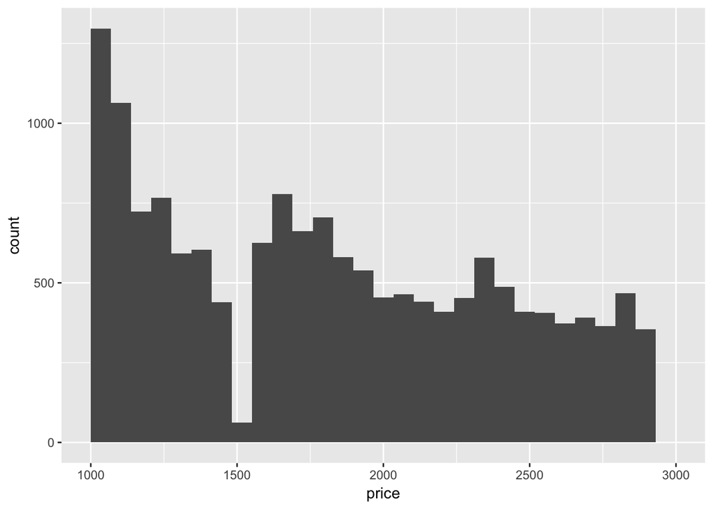

```r
ggplot(diamonds) +
  geom_histogram(aes(x=price)) +
  xlim(1000,3000)
```

- The plot updates defaults to act on the specific range
- Think of it as filtering with dplyr and plotting the filtered data, instead of zooming in on a plot of all data